# Data Handling: Import, Cleaning and Visualisation

## Recap and warm-up

## Basic programming concepts

- Values, variables
- Vectors
- Matrices
- Loops
- Logical statements
- Control statements
- Functions

## Three tutorials

- Compute the mean with your own function
- Evolution in action: fast and slow sloths -> exercise session
- Append and lists -> exercise session

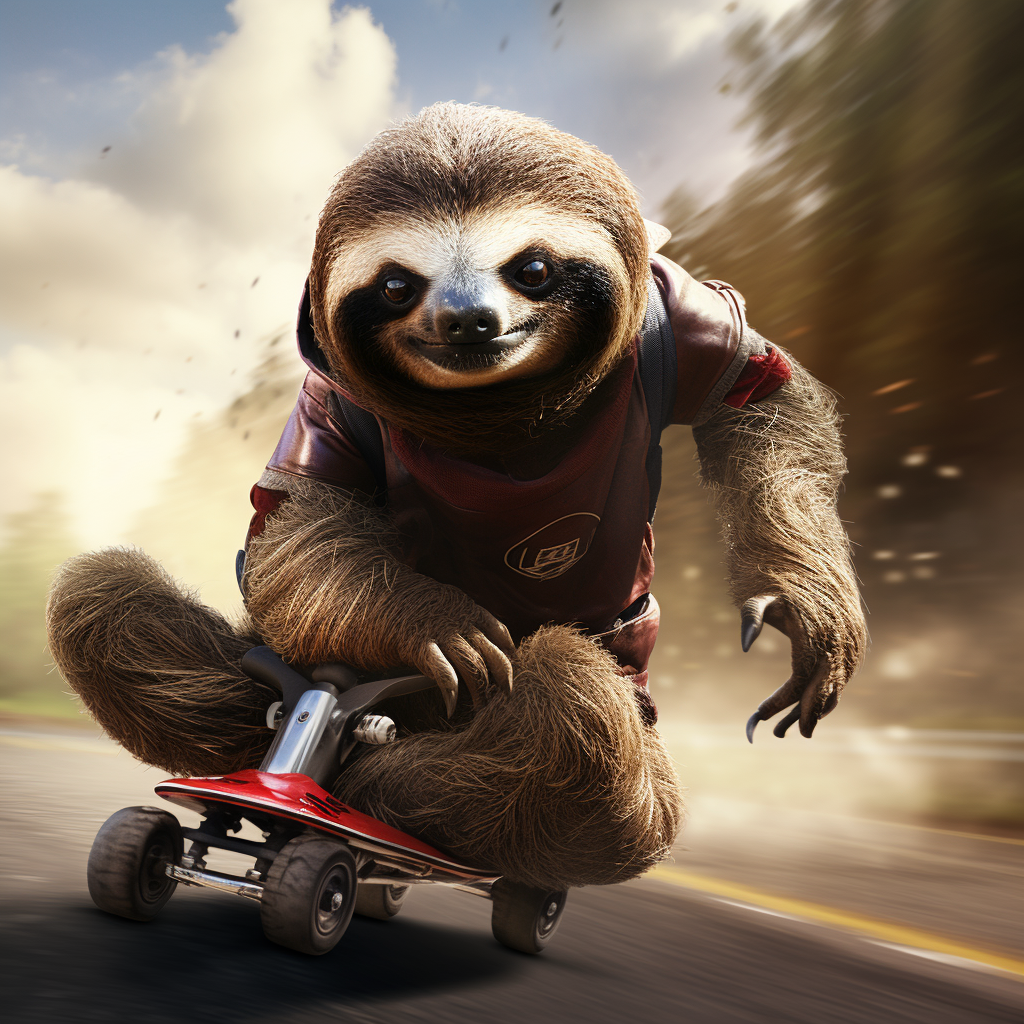

## Warm-up

```r
# Vectors
some_numbers <- c(30, 50, 60)

some_numbers[c(2,3)]
some_numbers > 3
some_numbers * 5
```

## Warm-up

What is `total_sum`?

```r
numbers <- 1:4
total_sum <- 0
n <- length(numbers)

# start loop
for (i in 1:n) {

  if(i %% 2 == 0){
     total_sum <- total_sum + numbers[i]
  } else {
    total_sum <- total_sum + 2*numbers[i]
  }

}
```

## Don’t forget…

[figure not shown]

## Data Processing

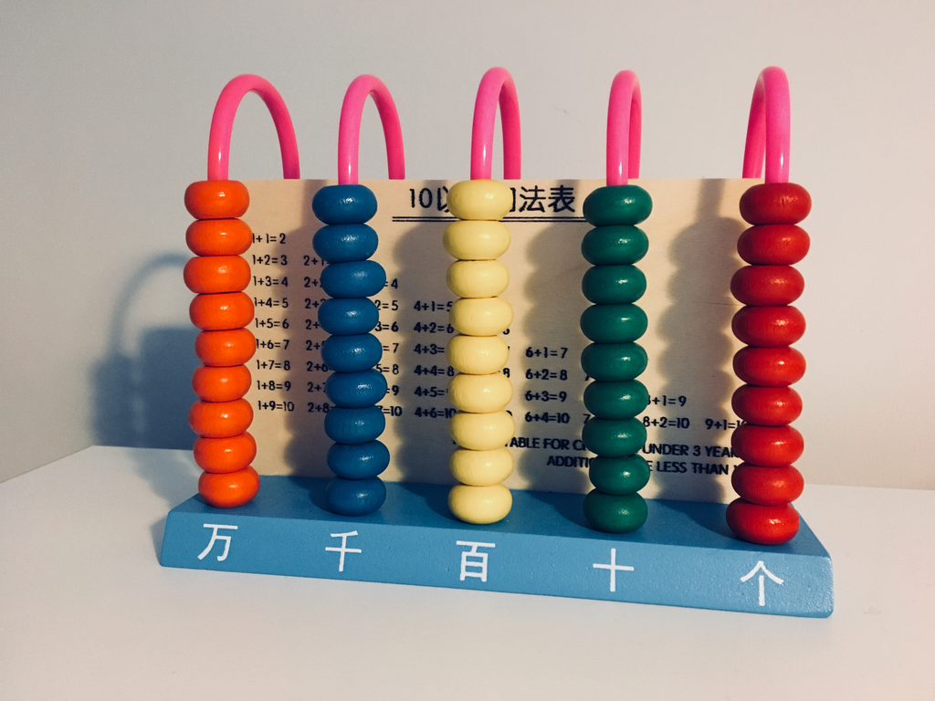

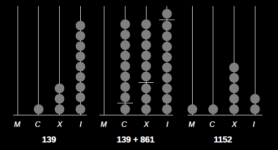

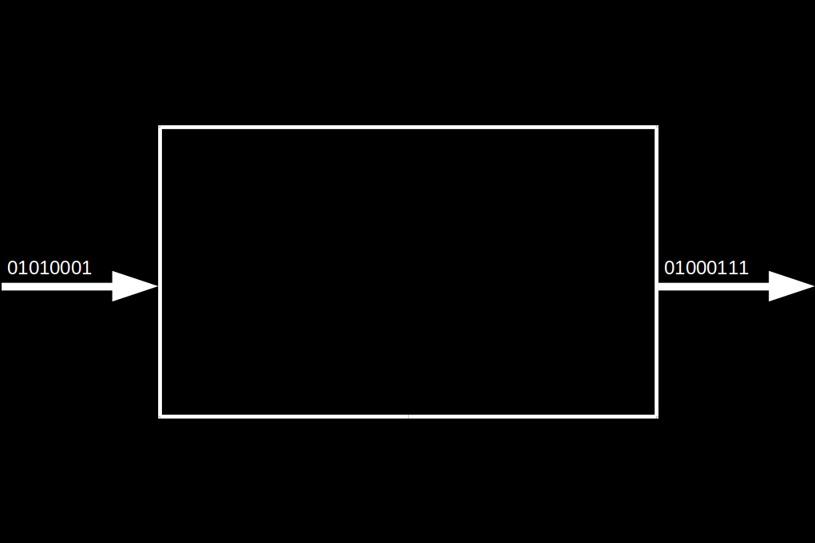

## The binary system

Microprocessors can only represent two signs (states):

- ‘Off’ = `0`
- ‘On’ = `1`

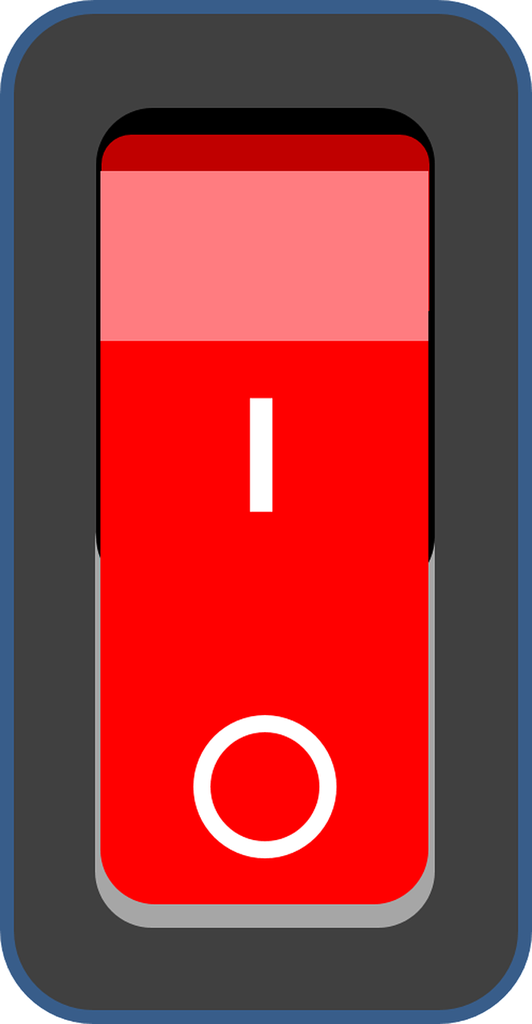

## The binary counting frame

- Only two signs: `0`, `1`.
- Base 2.
- Columns: \(2^0=1\), \(2^1=2\), \(2^2=4\), and so forth.

## The binary counting frame

What is the decimal number *139* in the binary counting frame?

## The binary counting frame

What is the decimal number *139* in the binary counting frame?

- Solution:

\[(1 \times 2^7) + (1 \times 2^3) + (1 \times 2^1) + (1 \times 2^0) = 139.\]

## The binary counting frame

What is the decimal number *139* in the binary counting frame?

- Solution:

\[(1 \times 2^7) + (1 \times 2^3) + (1 \times 2^1) + (1 \times 2^0) = 139.\]

- More precisely:

\[(1 \times 2^7) + (0 \times 2^6) + (0 \times 2^5) + (0 \times 2^4) + (1 \times 2^3)\\ + (0 \times 2^2) + (1 \times 2^1) + (1 \times 2^0) = 139.\]

- That is, the number `139` in the decimal system corresponds to `10001011` in the binary system.

## Conversion between binary and decimal

| Number | 128 | 64 | 32 | 16 | 8 | 4 | 2 | 1 |
| --- | --- | --- | --- | --- | --- | --- | --- | --- |

## Conversion between binary and decimal

| Number | 128 | 64 | 32 | 16 | 8 | 4 | 2 | 1 |
| --- | --- | --- | --- | --- | --- | --- | --- | --- |
| 0 = | 0 | 0 | 0 | 0 | 0 | 0 | 0 | 0 |
| 1 = | 0 | 0 | 0 | 0 | 0 | 0 | 0 | 1 |
| 2 = | 0 | 0 | 0 | 0 | 0 | 0 | 1 | 0 |
| 3 = | 0 | 0 | 0 | 0 | 0 | 0 | 1 | 1 |
| … |  |  |  |  |  |  |  |  |
| 139 = | 1 | 0 | 0 | 0 | 1 | 0 | 1 | 1 |

## The binary counting frame

- Sufficient to represent all *natural* numbers in the decimal system.

## The binary counting frame

- Sufficient to represent all *natural* numbers in the decimal system.
- Representing fractions is tricky
  - e.g. \(1/3=0.333..\) actually constitutes an infinite sequence of 0s and 1s.
  - Solution: ‘floating point numbers’ (not 100% accurate)

## Floating point numbers: a strange phenomenon

```r
# Subtracting two nearly identical floating-point numbers
x <- 0.3 - 0.2
y <- 0.1

# Check if they are equal
result <- x == y

print(x)
```

```
## [1] 0.1
```

```r
print(y)
```

```
## [1] 0.1
```

```r
print(result)
```

```
## [1] FALSE
```

## Floating point numbers: a strange phenomenon

```r
print(format(x, digits = 20))  # prints a more precise value of x
```

```
## [1] "0.099999999999999977796"
```

```r
print(format(y, digits = 20))  # prints a more precise value of y
```

```
## [1] "0.10000000000000000555"
```

```r
tolerance <- 1e-9
equal <- abs(x - y) < tolerance
print(equal)
```

```
## [1] TRUE
```

## Decimal numbers in a computer

If computers only understand `0` and `1`, how can they express decimal numbers like *139*?

## Decimal numbers in a computer

If computers only understand `0` and `1`, how can they express decimal numbers like *139*?

- *Standards* define how symbols, colors, etc are shown on the screen.
- Facilitates interaction with a computer (our keyboards do not only consist of a `0`/`1` switch).

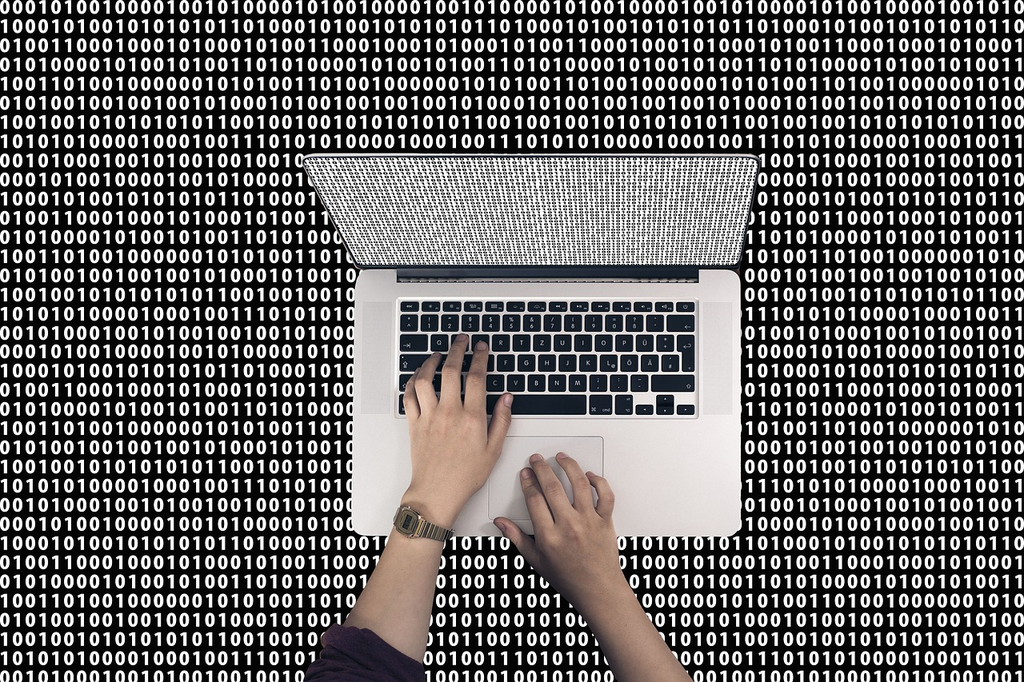

## What time is it?

[figure not shown]

## The hexadecimal system

- Binary numbers can become quite long rather quickly.
- Computer Science: refer to binary numbers with the *hexadecimal* system.

## The hexadecimal system

- *16 symbols*:
  - `0`-`9` (used like in the decimal system)…
  - and `A`-`F` (for the numbers 10 to 15).

## The hexadecimal system

- *16 symbols*:
  - `0`-`9` (used like in the decimal system)…
  - and `A`-`F` (for the numbers 10 to 15).
- *16 symbols >>> base 16*: each digit represents an increasing power of 16 (\(16^{0}\), \(16^{1}\), etc.).

## The hexadecimal system

What is the decimal number 139 expressed in the hexadecimal system?

## The hexadecimal system

What is the decimal number 139 expressed in the hexadecimal system?

- Solution: \[(8\times 16^1) + (11\times 16^0) = 139.\]
- More precisely: \[(8\times 16^1) + (B\times 16^0) = 8B = 139.\]
- Hence: `10001011` (in binary) = `8B` (in hexadecimal) = `139` in decimal.

## The hexadecimal system

Advantages (when working with binary numbers)

1. Shorter than raw binary representation
2. Much easier to translate forth and back between binary and hexadecimal than binary and decimal.

*WHY?*

😆

## Character Encoding

## Computers and text

How can a computer understand text if it only understands `0`s and `1`s?

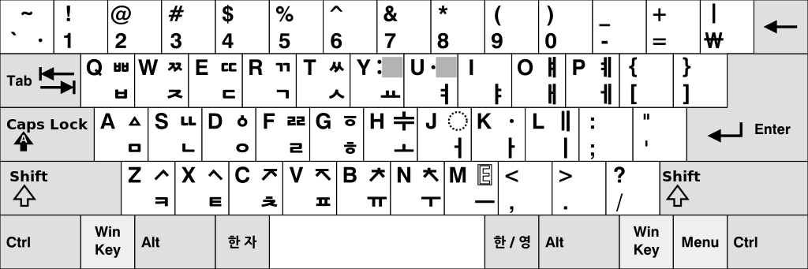

A modified version of South Korean Dubeolsik (two-set type) for old hangul letters. (Illustration by Yes0song 2010, [Creative Commons Attribution-Share Alike 3.0 Unported](https://creativecommons.org/licenses/by-sa/3.0/deed.en))

## Computers and text

How can a computer understand text if it only understands `0`s and `1`s?

- *Standards* define how `0`s and `1`s correspond to specific letters/characters of different human languages.
- These standards are usually called *character encodings*.
- Coded character sets that map unique numbers (in the end in binary coded values) to each character in the set.

## Computers and text

How can a computer understand text if it only understands `0`s and `1`s?

- *Standards* define how `0`s and `1`s correspond to specific letters/characters of different human languages.
- These standards are usually called *character encodings*.
- Coded character sets that map unique numbers (in the end in binary coded values) to each character in the set.
- For example, ASCII (American Standard Code for Information Interchange), now superseded by **utf-8** (Unicode).

## ASCII Table

| Binary | Hexadecimal | Decimal | Character |
| --- | --- | --- | --- |
| 0011 1111 | 3F | 63 | `?` |
| 0100 0001 | 41 | 65 | `A` |
| 0110 0010 | 62 | 98 | `b` |

## Character encodings: why should we care?

## Character encodings: why should we care?

- In practice, Data Science means handling digital data of all formats and shapes.
  - Diverse sources.
  - Different standards.
  - Different languages (Japanese vs English).
  - *read*/*store* data.
- At the lowest level, this means understanding/handling encodings.

## Computer Code and Text-Files

## Putting the pieces together…

Two core themes of this course:

1. How can *data* be *stored* digitally and be *read* by/imported to a computer?
2. How can we give instructions to a computer by writing *computer code*?

## Putting the pieces together…

Two core themes of this course:

1. How can *data* be *stored* digitally and be *read* by/imported to a computer?
2. How can we give instructions to a computer by writing *computer code*?

In both of these domains we mainly work with one simple type of document: *text files*.

## Text-files

- A *collection of characters* stored in a designated part of the computer memory/hard drive.
- An easy-to-read representation of the underlying information (`0`s and `1`s)!

## Text-files

- A *collection of characters* stored in a designated part of the computer memory/hard drive.
- An easy to read representation of the underlying information (`0`s and `1`s)!
- Common device to store data:
  - Structured data (tables)
  - Semi-structured data (websites)
  - Unstructured data (plain text)
- Typical device to store computer code.

## Text-editors: RStudio, Atom, VsCode

[figure not shown]

[figure not shown]

[figure not shown]

Install RStudio from [here](https://www.rstudio.com/products/rstudio/download/#download)!

Install Atom from [here](https://flight-manual.atom.io/getting-started/sections/installing-atom/)!

Install VScode from [here](https://code.visualstudio.com/)!

Install Sublime text from [here](https://www.sublimetext.com/)!

## Data Processing Basics

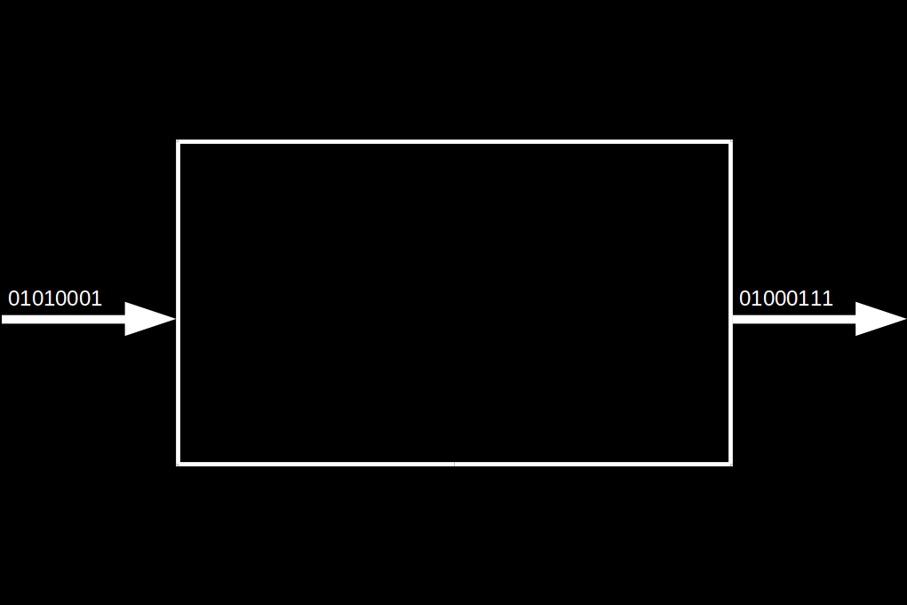

The ‘blackbox’ of data processing.

## Components of a standard computing environment

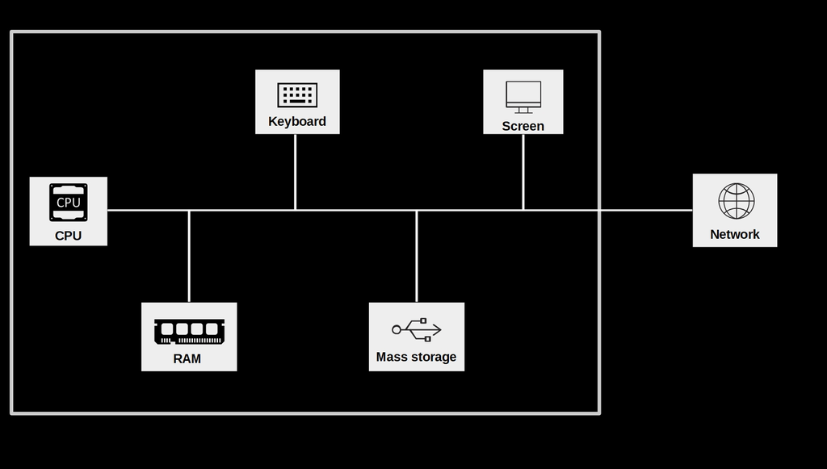

Basic components of a standard computing environment.

## Central Processing Unit

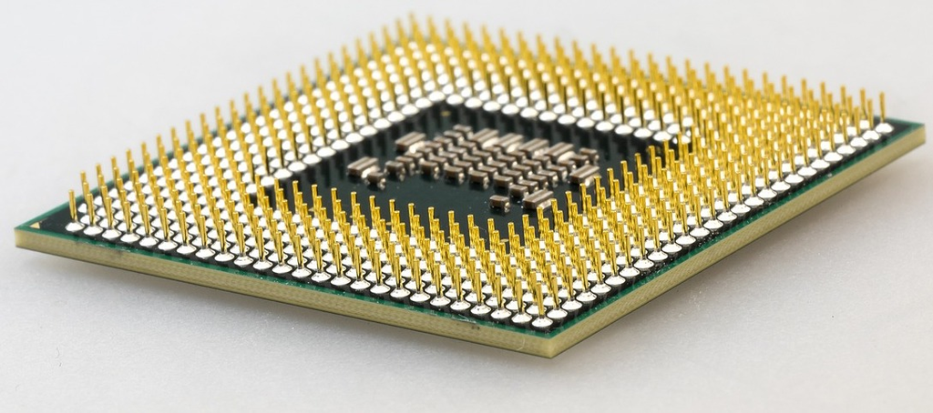

- R runs on one *CPU core* by default.
- All modern CPUs have multiple cores.
- *Advanced*: explore parallelization with `plyr`, `doParallel()` and `future`

## Random Access Memory

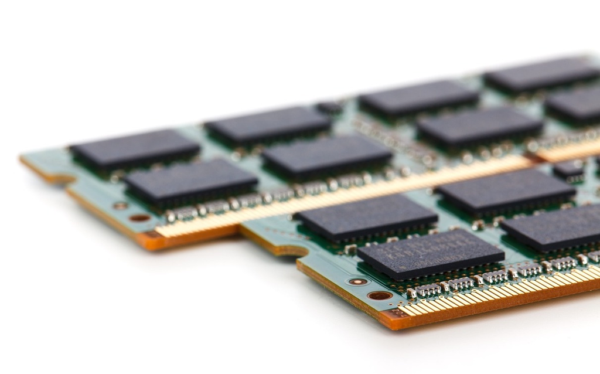

## Random Access Memory

```r
large_matrix <- matrix(1, nrow=1e8, ncol=1e8)
```

```
## Error in matrix(1, nrow = 1e+08, ncol = 1e+08): Vektor ist zu groß
```

- Try to create a matrix with \(10^8 \times 10^8\) elements.
- Assuming each number is stored using 8 bytes, this matrix would require \(8\times10^16\) bytes of RAM (more on bytes in the next lecture).

## Mass storage: hard drive

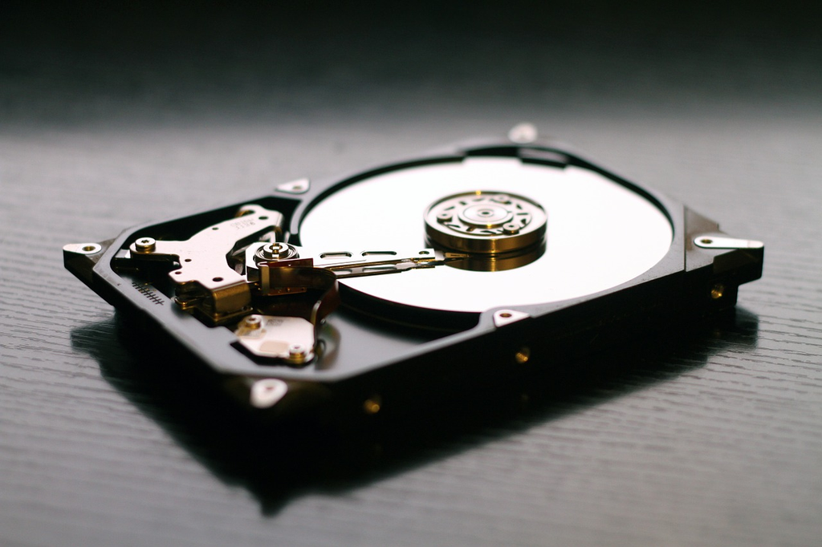

## Network: Internet, cloud, etc.

[figure not shown]

## Putting the pieces together…

Recall the initial example (survey) of this course.

1. Access a website (over the Internet), use keyboard to enter data into a website (a Google sheet in that case).
2. R program accesses the data of the Google sheet (again over the Internet), downloads the data, and loads it into RAM.
3. Data processing: produce output (in the form of statistics/plots), output on screen.

*5468616E6B7320616E642073656520796F75206E657874207765656B21*

🤓